# ggplot2によるデータ可視化

```r
libs <- c("bench", "tidyverse", "yaml", "rvest")
for (lib in libs)
  require(lib, character.only = TRUE)
config <- read_yaml( "config.yaml" )
```

# ggplot2を用いた可視化

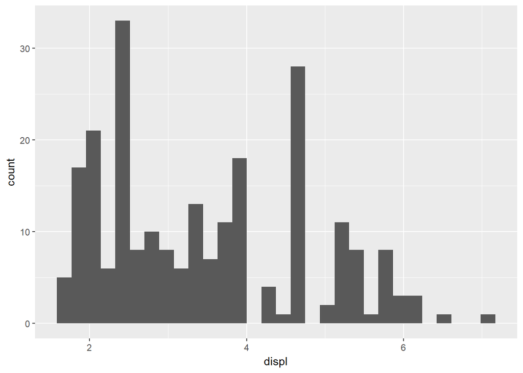

```r
# 下地
g <- ggplot()

# ヒストグラム
# binの大きさは自動で設定してくれる
ggplot() +
  geom_histogram(data = mpg, mapping = aes(x = displ))
```

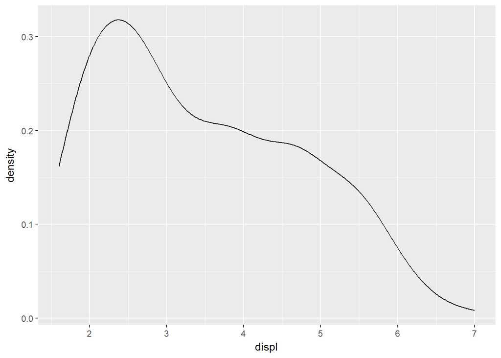

```r
# 密度分布
# geom_densityで描くとキレイではないので, lineでstatをdensityにする
ggplot(mpg) +
  geom_line(mapping = aes(x = displ), stat = "density")
```

色を分けたい場合には変数を因子型として離散変数と見なされる ように配慮する

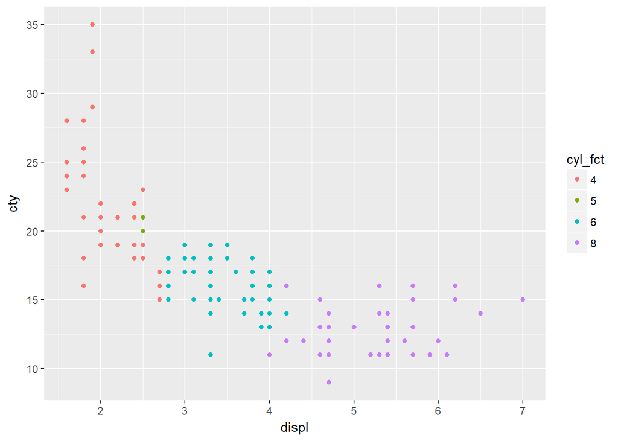

```r
mpg %>%
  mutate(cyl_fct = factor(cyl, levels = 4:8, order = TRUE)) %>%
  ggplot(mapping = aes(x = displ, y = cty, group = cyl_fct, colour = cyl_fct)) +
  geom_point()
```

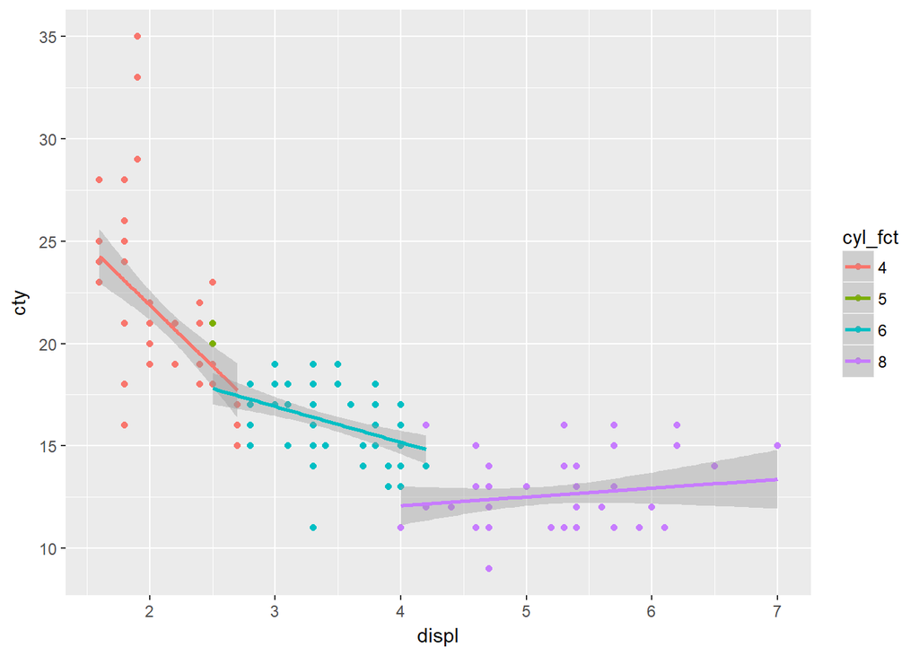

```r
# グループ化することで近似曲線も描ける

mpg %>%
  mutate(cyl_fct = factor(cyl, levels = 4:8, order = TRUE)) %>%
  ggplot(mapping = aes(x = displ, y = cty, group = cyl_fct, colour = cyl_fct)) +
  geom_point() +
  geom_smooth(method = "lm")
```

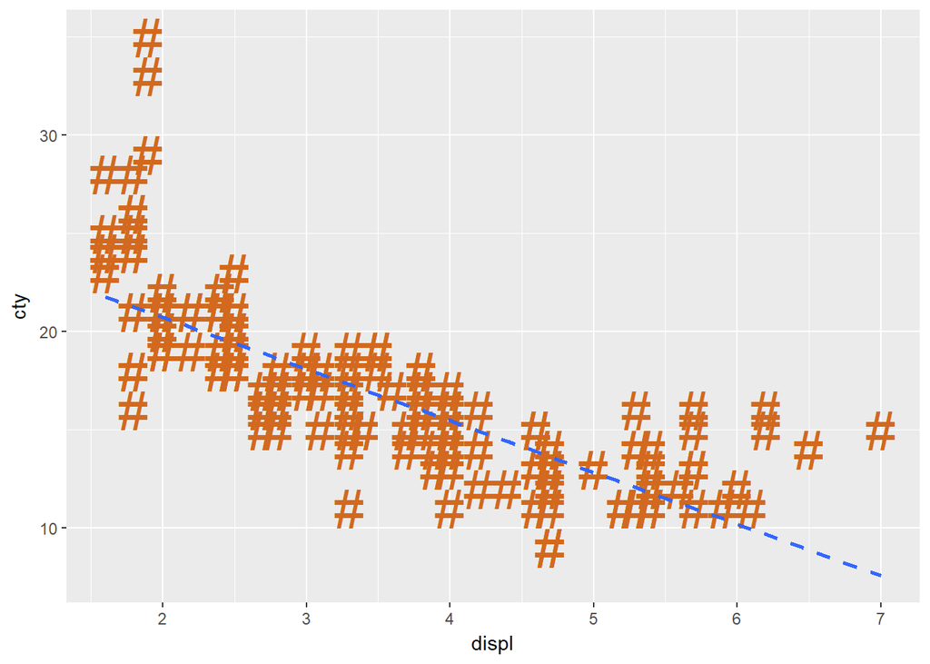

```r
# こんな絵も記述できる
ggplot(data=mpg, mapping = aes(x = displ, y = cty)) +
  geom_point(colour = "chocolate", shape = 35, size = 10) +
  geom_smooth(method = "lm", linetype = "dashed", se = FALSE)
```

## annotate

データセットではないが, 簡易的に, つまりはベクトルで データを追加したい場合にはannotateを使う.

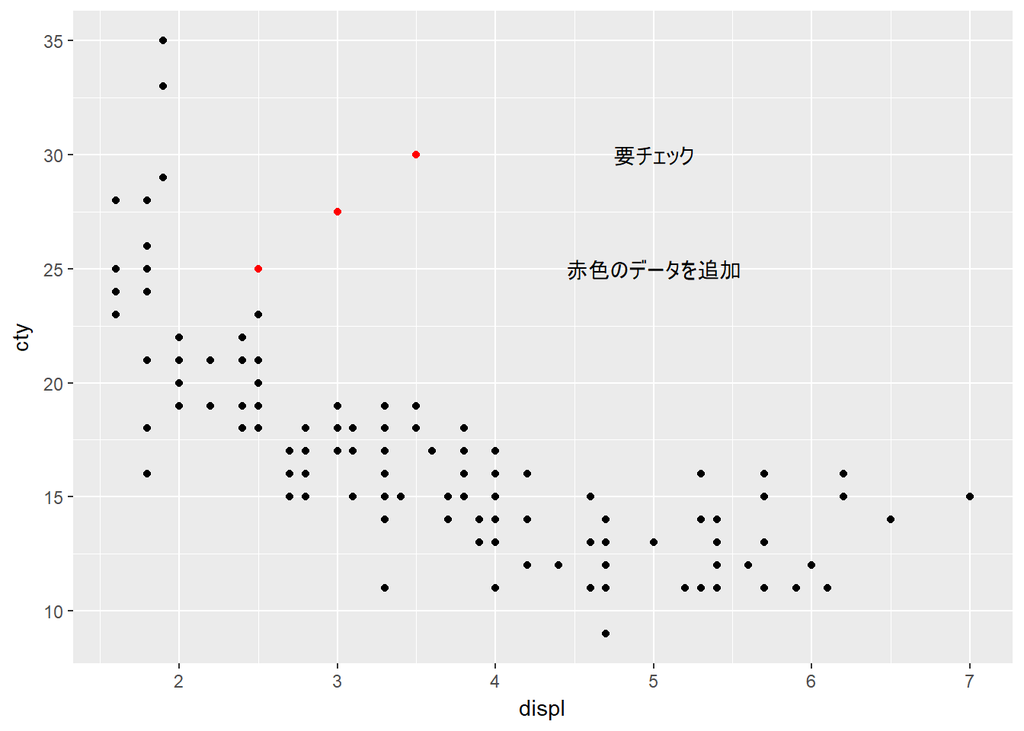

```r
add_x <- c(2.5, 3, 3.5)
add_y <- c(25, 27.5, 30)

ggplot(data = mpg, mapping = aes(x = displ, y = cty)) +
  geom_point() +
  annotate(geom = "point", x = add_x, y = add_y, colour = "red") +
  annotate(geom = "text", x = c(5, 5), y = c(30, 25), label = c("要チェック", "赤色のデータを追加"))
```

## 統計処理

x軸が離散変数の場合.

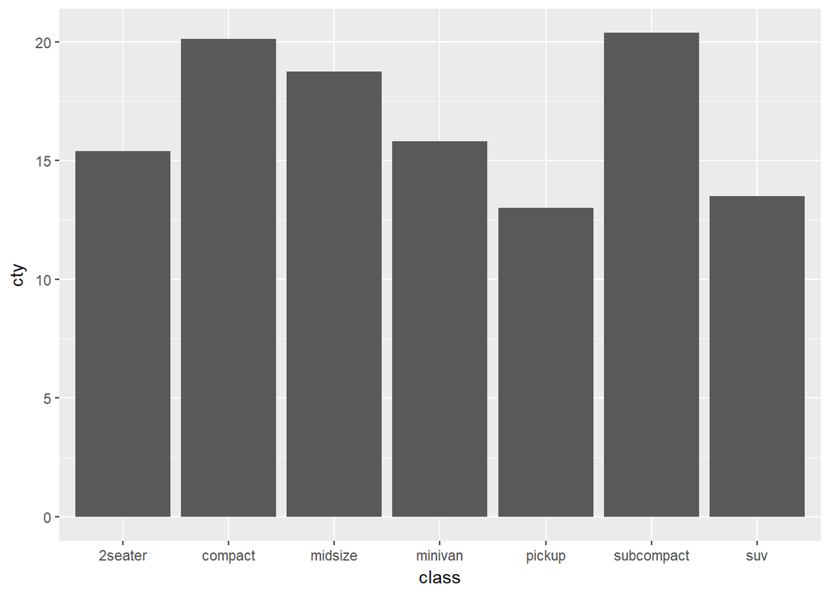

```r
mean_cty <-
  mpg %>%
  group_by(class) %>%
  summarise(cty = mean(cty))

ggplot(mean_cty, aes(class, cty)) +
  geom_bar(stat = "identity")
```

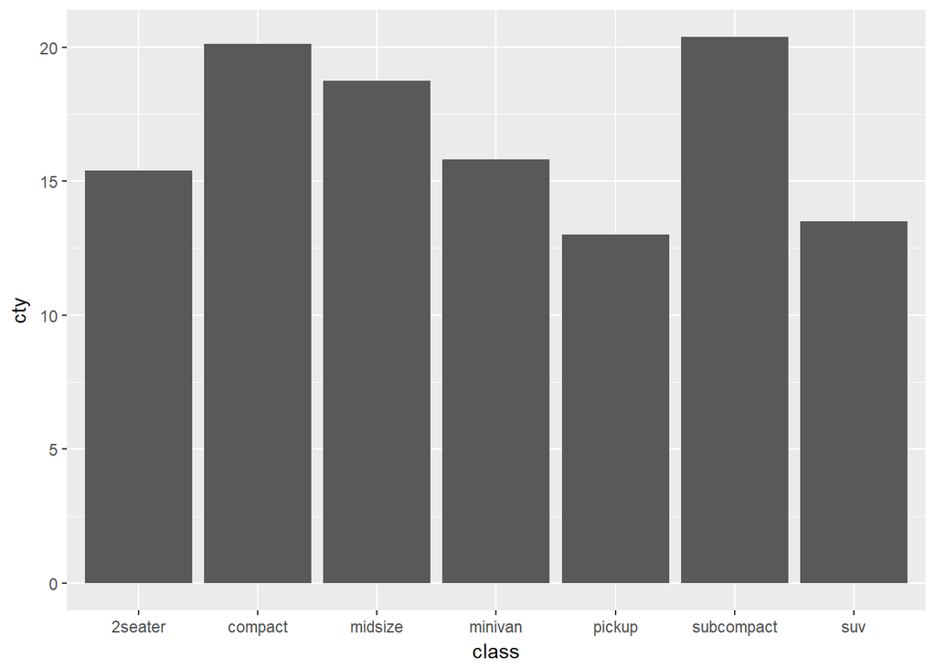

```r
ggplot(mpg, aes(class, cty)) +
  geom_bar(stat = "summary", fun.y = "mean")
```

要約統計量を知る. 関数はオリジナルでも大丈夫のよう.

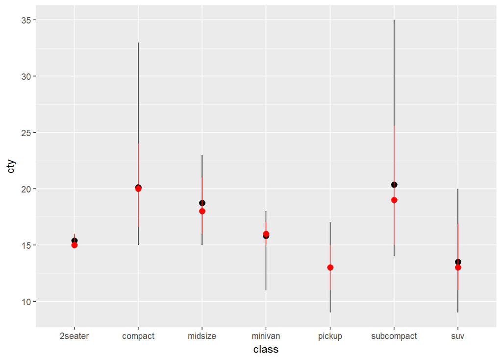

```r
q10 <- partial(quantile, prob = .1)
q90 <- partial(quantile, prob = .9)
mpg %>%
  ggplot(mapping = aes(x = class, y = cty)) +
  stat_summary(geom = "pointrange", fun.y = "mean", fun.ymax = "max", fun.ymin = "min") +
  stat_summary(geom = "pointrange", fun.y = "median", fun.ymax = "q90", fun.ymin = "q10", colour ="red")
```

ヴァイオリンプロットは面積に情報を持たせることができる. このグラフを見ると, 点が重なってしまっていることがわかる.

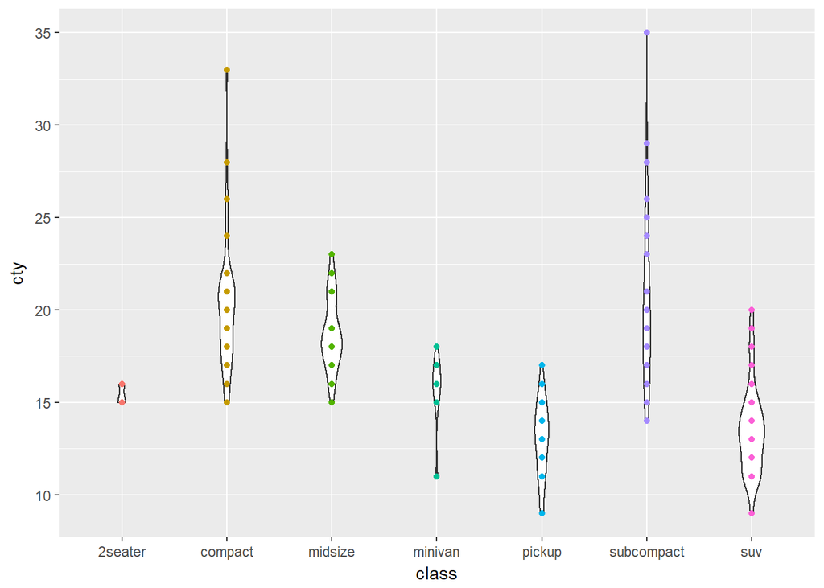

```r
ggplot(data = mpg, mapping = aes(x = class, y = cty)) +
  geom_violin(scale = "count") +
  geom_point(mapping = aes(colour = class), show.legend = FALSE)
```

jitterで点の重なりを避ける.

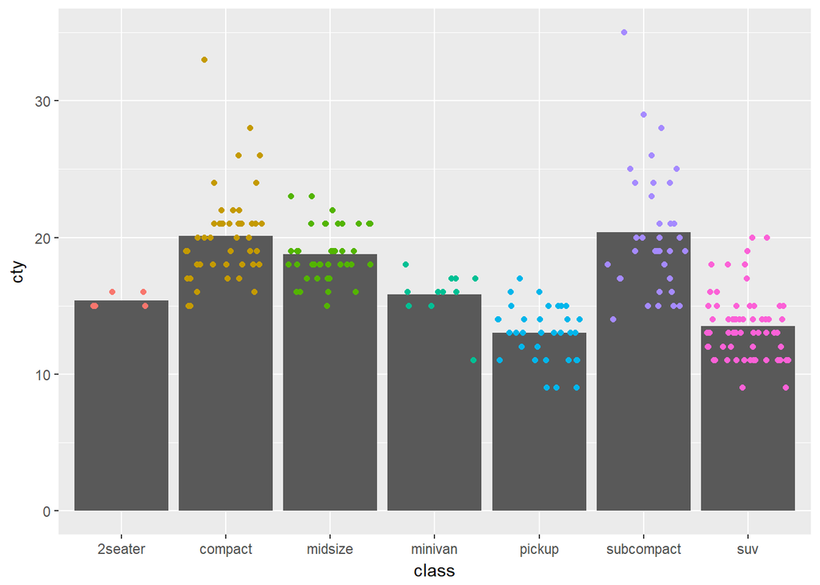

```r
ggplot(data = mpg, mapping = aes(x = class, y = cty)) +
  stat_summary(geom = "bar", fun.y = "mean") +
  geom_jitter(mapping = aes(colour = class), width = .4, height = .0, show.legend = FALSE)
```

## position

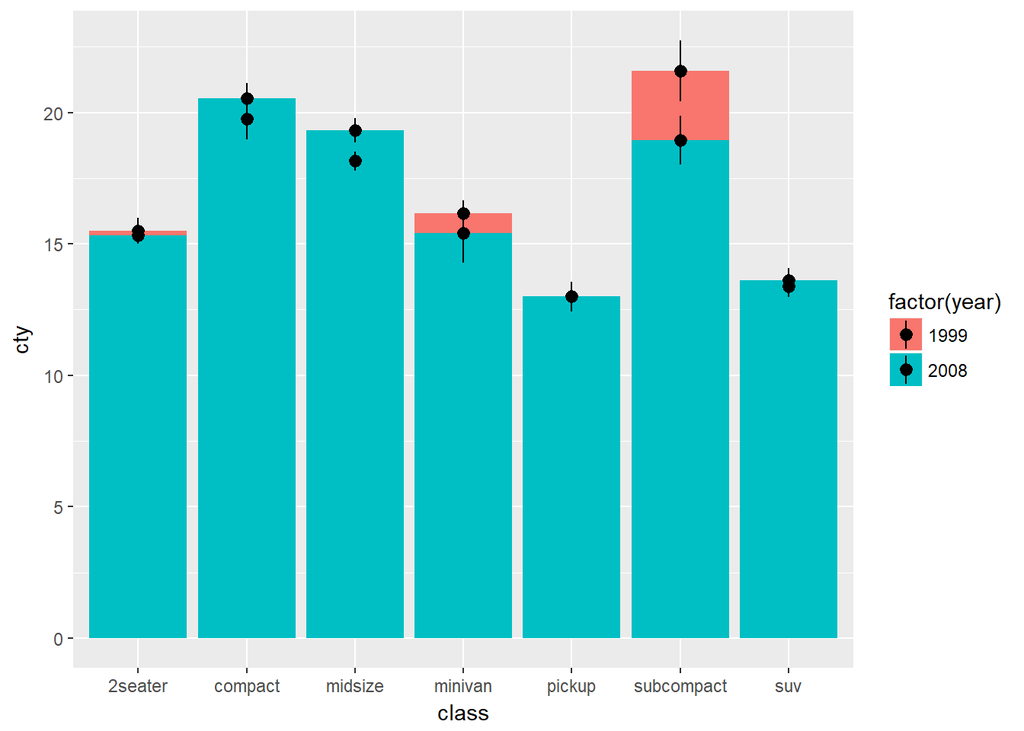

```r
ggplot(data = mpg, mapping = aes(x = class, y = cty, fill = factor(year)))+
stat_summary(geom = "bar", fun.y = "mean")+
stat_summary(fun.data = "mean_se")
```

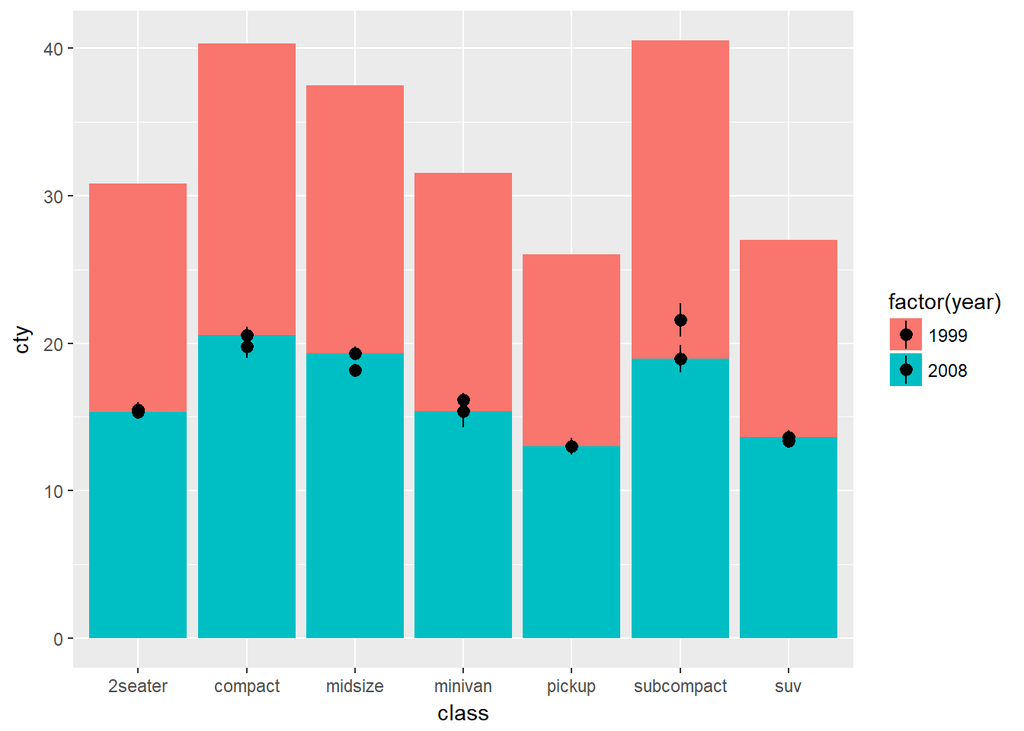

```r
# 中央：position = "stack"
ggplot(data = mpg, mapping = aes(x = class, y = cty, fill = factor(year)))+
geom_bar(stat = "summary", fun.y = "mean")+
stat_summary(fun.data = "mean_se")
```

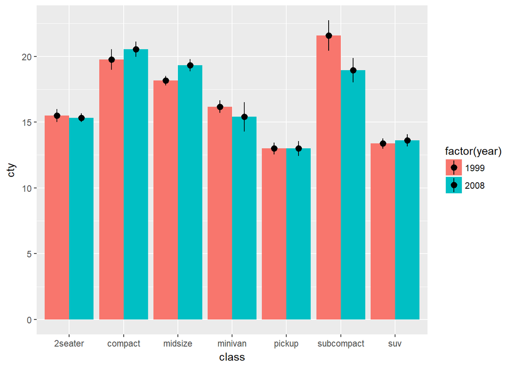

```r
# 右図：position = "dodge"
ggplot(data = mpg, mapping = aes(x = class, y = cty, fill = factor(year)))+
stat_summary(geom = "bar", fun.y = "mean", position = position_dodge())+
stat_summary(fun.data = "mean_se", position = position_dodge(width = 0.9))
```

## 特定の範囲を拡大表示

coord_cartesianを使う.

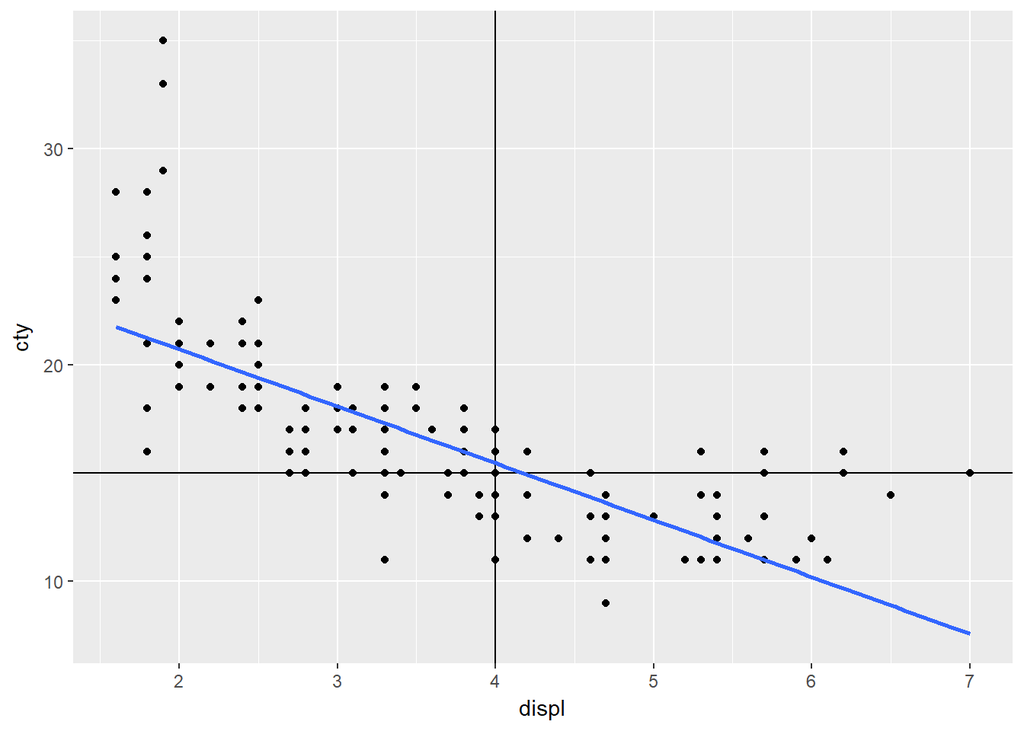

```r
ggplot(data = mpg, mapping = aes(x = displ, y = cty)) +
geom_point() +
geom_vline(xintercept = 4) +
geom_hline(yintercept = 15) +
geom_smooth(method = "lm", se = FALSE)
```

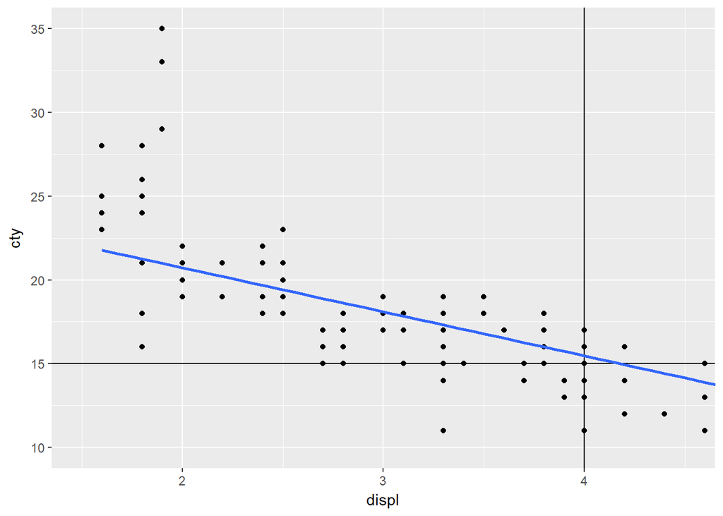

```r
# 右図：X軸、Y軸の特定の範囲を拡大表示した場合
ggplot(data = mpg, mapping = aes(x = displ, y = cty)) +
geom_point() +
coord_cartesian(xlim = c(1.5, 4.5), ylim = c(10, 35)) +
geom_vline(xintercept = 4) +
geom_hline(yintercept = 15) +
geom_smooth(method = "lm", se = FALSE)
```

# 他者と共有可能な状態に仕上げる

themeで頑張れる. themeをどのように使うのかは, theme_bw()の中身や結果を 確かめながらやる.

```r
# 関数としてのtheme
theme_bw
```

```
## function (base_size = 11, base_family = "")
## {
##     theme_grey(base_size = base_size, base_family = base_family) %+replace%
##         theme(panel.background = element_rect(fill = "white",
##             colour = NA), panel.border = element_rect(fill = NA,
##             colour = "grey20"), panel.grid.major = element_line(colour = "grey92"),
##             panel.grid.minor = element_line(colour = "grey92",
##                 size = 0.25), strip.background = element_rect(fill = "grey85",
##                 colour = "grey20"), legend.key = element_rect(fill = "white",
##                 colour = NA), complete = TRUE)
## }
## <bytecode: 0x000000001df704d0>
## <environment: namespace:ggplot2>
```

## 配色を自分で決める

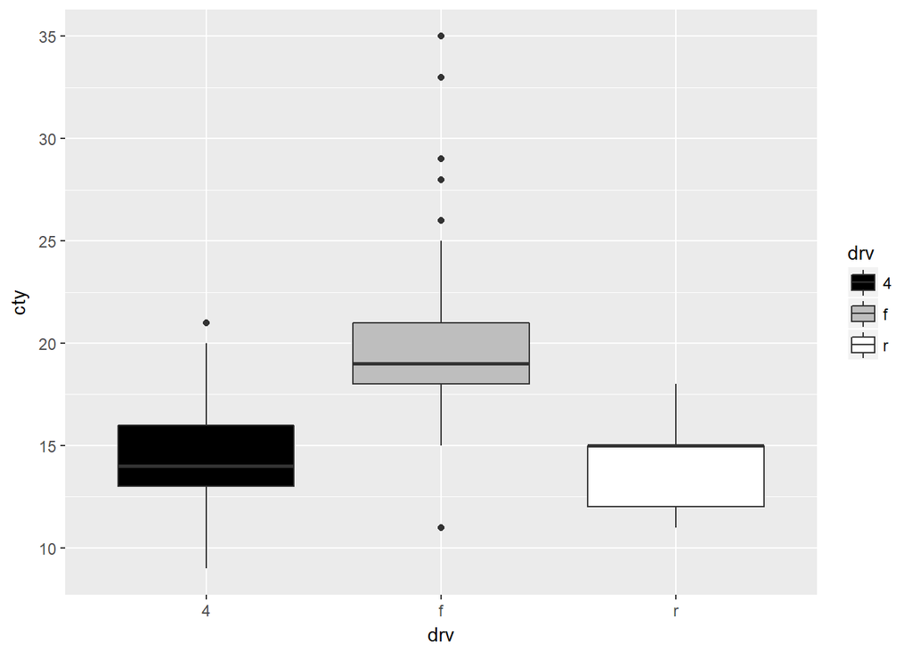

```r
ggplot(data = mpg, mapping = aes(x = drv, y = cty, fill = drv)) +
geom_boxplot() +
scale_fill_manual(values = c("4" = "black", "f" = "grey", "r" = "#ffffff"))
```

## ラベルを変更する

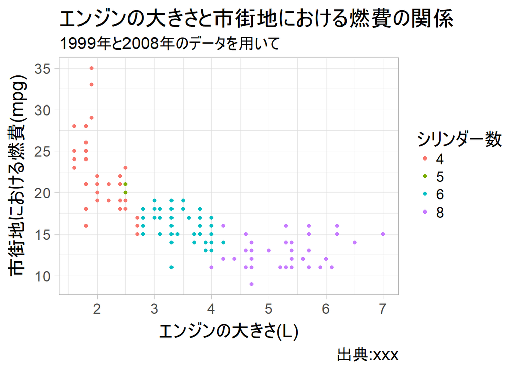

```r
ggplot(data = mpg, mapping = aes(x = displ, y = cty, group = factor(cyl), colour = factor(cyl))) +
  geom_point() +
  labs(
    title = "エンジンの大きさと市街地における燃費の関係",
    subtitle = "1999年と2008年のデータを用いて",
    caption  = "出典:xxx",
    x = "エンジンの大きさ(L)",
    y = "市街地における燃費(mpg)",
    colour = "シリンダー数"
  ) +
  theme_light(base_size = 18)
```

## GUI

GUIベースでggplotやPlotyの設定できるのでとても便利. またはRStudioのアドインである[ggThemeAssist](https://github.com/calligross/ggthemeassist)を使えばよいらしい.

```r
library(ggplotgui)
ggplot_shiny(data = mpg)
```

ggplotオブジェクトを渡して, Plotlyを起動させることもできる. (著者の方に確認中)

## 複数のグラフを並べる

- gridExtra::grid.arrange
- cowplot::plot_grid
- ggpubr::ggarrange

```r
library(ggpubr)
```

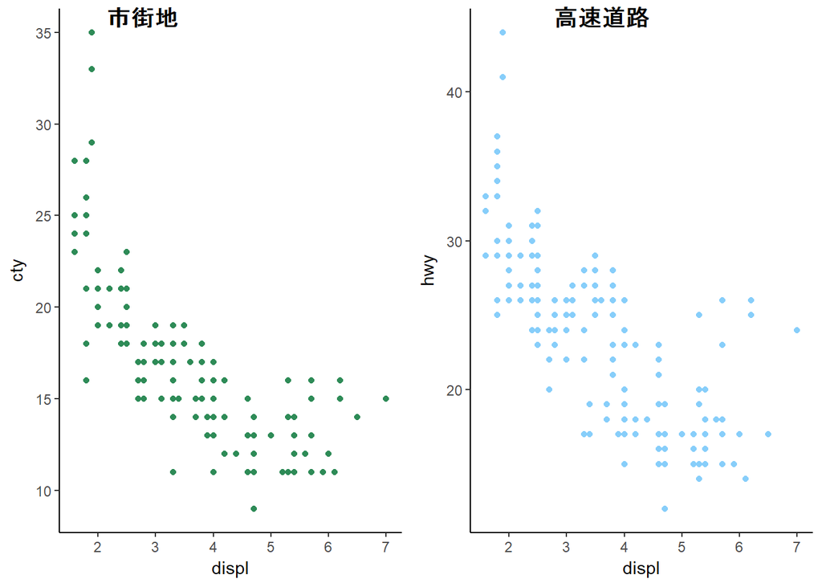

```r
g1 <- ggplot(data = mpg, mapping = aes(x = displ, y = cty)) +
theme_classic() +
geom_point(colour = "seagreen")
g2 <- ggplot(data = mpg, mapping = aes(x = displ, y = hwy)) +
theme_classic() +
geom_point(colour = "lightskyblue")
ggarrange(g1, g2, labels = c("市街地", "高速道路"), ncol = 2, hjust = -1.5)
```

## 色に配慮する

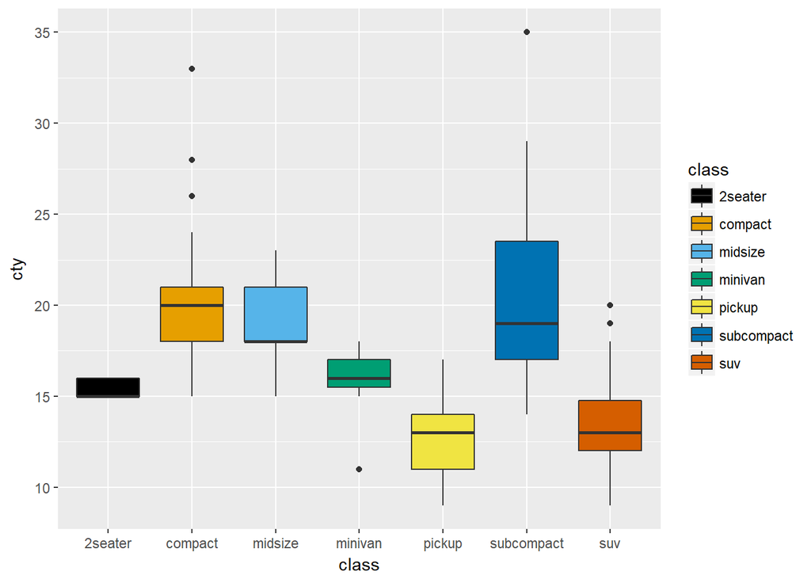

```r
library(ggthemes)
ggplot(data = mpg, mapping = aes(x = class, y = cty, fill = class)) +
 geom_boxplot(show.legend = TRUE) +
 scale_fill_colorblind()
```